# PROYCETO N°1

SANTANA GUERRA MANUEL

2024-12-19

## CARACTERÍSTICAS DE LA DATA

Se tiene una base de datos de una aseguradora de riesgos o siniestro, que cubre a sus clientes el gasto de diversos tipos de siniestros con distintos tipos de montos según el tipo, asi mismo dado el contexto de analizar una base de datos grande y de una aseguradora es posible encontrar valores elevados en los saldos de la aseguradora con sus clientes a desembolsar por algún tipo de siniestro ocurrido,y viceversa tambien podria haber clientes con cierta deuda elevada.Por otro lado, la antiguedad de los cliente tambien podria existir valor elevados que distan mucho de la media, dado la antiguedad de los clientes, de los tipos de contratos y coberturas de la poliza de los seguros. Se menciona que se utlizo a winsocrización para lidiar el impacto de los valores outliers, teniendo encuenta que poria ser factible que hubieran valores alevados en so desembolsos por los seguros de siniestro ciertas deudas, dada una cantidad de siniestro ocurridos y su gravedad.Se utlizó para suavizar dichos valores.

A continuación, se muestra un cuadro del resumen de las variables de la base de datos.

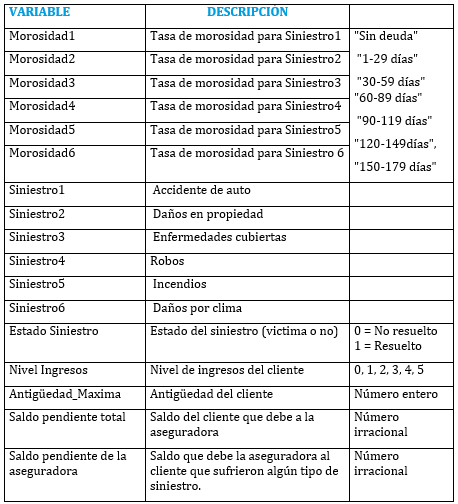

SINIESTROS

# INICIANDO EL PROCESO EN R - RSTUDIO

```r
library(ggplot2)
library(dplyr)
library(gridExtra)
library(Hmisc)
library(e1071)
library(corrplot)
library(ParamHelpers)
library(mlr)
library(VIM)
library(statsr)
library(MASS)
set.seed(567)
setwd("D:/EconomymanuR/proyecto")
df <- read.csv("df.csv",
               header = TRUE,
               comment.char = "#",
               fileEncoding = "Latin1")
View(df)
```

Se le pide al software que nos muestre características de nuestra data.

```r
colnames(df)
```

```
##  [1] "Cliente_ID"          "Antigüedad_Maxima"   "Nivel_Ingresos"
##  [4] "Saldo_Pendiente"     "Puntaje_Morosidad1"  "Puntaje_Morosidad2"
##  [7] "Puntaje_Morosidad3"  "Puntaje_Morosidad4"  "Puntaje_Morosidad5"
## [10] "Puntaje_Morosidad6"  "Saldo_Pendiente_Seg" "Siniestros1"
## [13] "Siniestros2"         "Siniestros3"         "Siniestros4"
## [16] "Siniestros5"         "Siniestros6"         "Estado_Siniestro"
```

```r
nrow(df)
```

```
## [1] 5800
```

```r
ncol(df)
```

```
## [1] 18
```

```r
dim(df)
```

```
## [1] 5800   18
```

```r
str(df)
```

```
## 'data.frame':    5800 obs. of  18 variables:
##  $ Cliente_ID         : int  185 238 346 460 549 559 666 676 696 907 ...
##  $ Antigüedad_Maxima  : int  44 79 102 NA 109 183 172 76 136 171 ...
##  $ Nivel_Ingresos     : int  1 1 1 1 NA NA 0 1 0 0 ...
##  $ Saldo_Pendiente    : num  605 1006 299 645 218 ...
##  $ Puntaje_Morosidad1 : int  0 0 0 0 0 0 0 0 0 0 ...
##  $ Puntaje_Morosidad2 : int  0 0 0 0 0 0 0 0 0 0 ...
##  $ Puntaje_Morosidad3 : int  0 0 0 0 0 0 0 1 0 0 ...
##  $ Puntaje_Morosidad4 : int  0 0 0 0 0 0 0 0 0 0 ...
##  $ Puntaje_Morosidad5 : int  0 0 0 0 0 0 0 0 0 0 ...
##  $ Puntaje_Morosidad6 : int  0 0 0 0 0 0 0 0 0 0 ...
##  $ Saldo_Pendiente_Seg: num  0 0 0 0 0 0 0 0 0 0 ...
##  $ Siniestros1        : int  0 0 0 0 0 0 0 0 0 0 ...
##  $ Siniestros2        : int  0 0 0 0 0 0 0 0 0 0 ...
##  $ Siniestros3        : int  0 0 0 0 0 0 0 0 0 0 ...
##  $ Siniestros4        : int  0 0 0 0 0 0 0 1 0 0 ...
##  $ Siniestros5        : int  0 0 0 0 0 0 0 1 0 0 ...
##  $ Siniestros6        : int  0 0 0 0 0 0 0 1 0 0 ...
##  $ Estado_Siniestro   : chr  "no" "no" "no" "no" ...
```

```r
na_por_variable <- sapply(df, function(x) sum(is.na(x)))
na_por_variable
```

```
##          Cliente_ID   Antigüedad_Maxima      Nivel_Ingresos     Saldo_Pendiente
##                   0                 587                 273                   0
##  Puntaje_Morosidad1  Puntaje_Morosidad2  Puntaje_Morosidad3  Puntaje_Morosidad4
##                   0                 186                 256                 340
##  Puntaje_Morosidad5  Puntaje_Morosidad6 Saldo_Pendiente_Seg         Siniestros1
##                 403                 476                   0                   0
##         Siniestros2         Siniestros3         Siniestros4         Siniestros5
##                   0                   0                   0                   0
##         Siniestros6    Estado_Siniestro
##                   0                   0
```

# TRANSFORMACIÓN DE LAS VARIABLES

Se transforman las variables según el diccionario del proyecto y la interpretación de esta.

```r
df$Nivel_Ingresos <- factor(df$Nivel_Ingresos,levels = c(0, 1, 2, 3,                             4, 5),ordered = TRUE)

df$Puntaje_Morosidad1 <- factor(df$Puntaje_Morosidad1,
                levels = c(0, 1, 2, 3, 4, 5, 6),
                labels = c("Sin deuda", "1-29 días", "30-59 días",                              "60-89 días", "90-119 días","120-149días",
                            "150-179 días"), ordered = TRUE)

variables_morosidad <- c("Puntaje_Morosidad2", "Puntaje_Morosidad3",
                         "Puntaje_Morosidad4", "Puntaje_Morosidad5",
                         "Puntaje_Morosidad6")

niveles_validos <- 0:6
etiquetas <- c("Sin deuda", "1-29 días", "30-59 días","60-89 días",
               "90-119 días", "120-149 días", "150-179 días")
# Bucle para transformar las variables
for (var in variables_morosidad) {
  #Reemplazar valores atípicos (7) por NA
  df[[var]] <- ifelse(df[[var]] %in% niveles_validos, df[[var]], NA)
  # Convertir a factor ordenado con niveles y etiquetas
  df[[var]] <- factor(df[[var]], levels = niveles_validos, labels =    etiquetas, ordered = TRUE)}

# Convertir Estado_Siniestro a factor
df$Estado_Siniestro <- as.factor(df$Estado_Siniestro)
df$Estado_Siniestro[!(df$Estado_Siniestro %in% c("si", "no"))] <- "no"
df$Estado_Siniestro <- droplevels(df$Estado_Siniestro)
```

```r
# Verificar si las variables se transformaron correctamente
lapply(df[variables_morosidad], summary)
```

```
## $Puntaje_Morosidad2
##    Sin deuda    1-29 días   30-59 días   60-89 días  90-119 días 120-149 días
##         4941          390          137           58           22            9
## 150-179 días         NA's
##            3          240
##
## $Puntaje_Morosidad3
##    Sin deuda    1-29 días   30-59 días   60-89 días  90-119 días 120-149 días
##         4915          394          115           44           15            5
## 150-179 días         NA's
##           12          300
##
## $Puntaje_Morosidad4
##    Sin deuda    1-29 días   30-59 días   60-89 días  90-119 días 120-149 días
##         4886          385           98           28            5           13
## 150-179 días         NA's
##            8          377
##
## $Puntaje_Morosidad5
##    Sin deuda    1-29 días   30-59 días   60-89 días  90-119 días 120-149 días
##         4830          391           96           18           15           10
## 150-179 días         NA's
##            5          435
##
## $Puntaje_Morosidad6
##    Sin deuda    1-29 días   30-59 días   60-89 días  90-119 días 120-149 días
##         4784          392           72           25           11            7
## 150-179 días         NA's
##            4          505
```

```r
table(df$Estado_Siniestro)
```

```
##
##   no   si
## 5304  496
```

```r
table(df$Nivel_Ingresos)
```

```
##
##    0    1    2    3    4    5
## 1915 2496  283  529  248   56
```

```r
table(df$Puntaje_Morosidad1)
```

```
##
##    Sin deuda    1-29 días   30-59 días   60-89 días  90-119 días  120-149días
##         5158          363          127          102           26           15
## 150-179 días
##            9
```

```r
table(df$Estado_Siniestro)
```

```
##
##   no   si
## 5304  496
```

# VALORES NA O NULOS- PERDIDOS

Para tratar los valores NA debemos de identificar en que variables se tienen estos valores, así mismo en función al tipo de variables y sus características se procederá a la imputación correspondiente.

```r
# IDENTIFICACIÓN DE LOS VALORES NAS
na_por_variable <- sapply(df, function(x) sum(is.na(x)))
na_por_variable
```

```
##          Cliente_ID   Antigüedad_Maxima      Nivel_Ingresos     Saldo_Pendiente
##                   0                 587                 273                   0
##  Puntaje_Morosidad1  Puntaje_Morosidad2  Puntaje_Morosidad3  Puntaje_Morosidad4
##                   0                 240                 300                 377
##  Puntaje_Morosidad5  Puntaje_Morosidad6 Saldo_Pendiente_Seg         Siniestros1
##                 435                 505                   0                   0
##         Siniestros2         Siniestros3         Siniestros4         Siniestros5
##                   0                   0                   0                   0
##         Siniestros6    Estado_Siniestro
##                   0                   0
```

# IMPUTAR VALORES NA: VARIABLES CUALITATIVAS

La imputación de de valores perdidos de las variables cualitativas será en función de la moda.

```r
# Imputación de los valores NA de la variable morosidad
# Función  moda
Mode <- function(x) {
  uniq_x <- unique(x)
  uniq_x[which.max(tabulate(match(x, uniq_x)))]}

# Imputar los valores NA con la moda
df <- df %>% mutate(Puntaje_Morosidad1 = if_else(is.na(Puntaje_Morosidad1), Mode(na.omit(Puntaje_Morosidad1)), Puntaje_Morosidad1),
    Puntaje_Morosidad2 = if_else(is.na(Puntaje_Morosidad2), Mode(na.omit(Puntaje_Morosidad2)), Puntaje_Morosidad2),
    Puntaje_Morosidad3 = if_else(is.na(Puntaje_Morosidad3), Mode(na.omit(Puntaje_Morosidad3)), Puntaje_Morosidad3),
    Puntaje_Morosidad4 = if_else(is.na(Puntaje_Morosidad4), Mode(na.omit(Puntaje_Morosidad4)), Puntaje_Morosidad4),
    Puntaje_Morosidad5 = if_else(is.na(Puntaje_Morosidad5), Mode(na.omit(Puntaje_Morosidad5)), Puntaje_Morosidad5),
    Puntaje_Morosidad6 = if_else(is.na(Puntaje_Morosidad6), Mode(na.omit(Puntaje_Morosidad6)), Puntaje_Morosidad6))

# imputación nivel de ingresos
calcular_moda <-function(x){as.numeric(names(sort(table(x),
                      decreasing =TRUE)[1]))}
moda_ingresos <- calcular_moda(df$Nivel_Ingresos)
print(moda_ingresos)
```

```
## [1] 1
```

```r
df$Nivel_Ingresos[is.na(df$Nivel_Ingresos)] <- moda_ingresos
# tabla para verificar los valores Na
na_por_variable <- sapply(df, function(x) sum(is.na(x)))
na_por_variable
```

```
##          Cliente_ID   Antigüedad_Maxima      Nivel_Ingresos     Saldo_Pendiente
##                   0                 587                   0                   0
##  Puntaje_Morosidad1  Puntaje_Morosidad2  Puntaje_Morosidad3  Puntaje_Morosidad4
##                   0                   0                   0                   0
##  Puntaje_Morosidad5  Puntaje_Morosidad6 Saldo_Pendiente_Seg         Siniestros1
##                   0                   0                   0                   0
##         Siniestros2         Siniestros3         Siniestros4         Siniestros5
##                   0                   0                   0                   0
##         Siniestros6    Estado_Siniestro
##                   0                   0
```

# TRATAMIENTO DE VALORES NA: VARIABLES CUANTITATIVAS

Se procede a observar las características de las variables a imputar,por ejemplo analizaremos sus estadísticos descriptivos y la distribución que tiene; ¿es simétrica?,¿es asimétrica con cola a la derecha o izquierda?

```r
sum(is.na(df$Antigüedad_Maxima))
```

```
## [1] 587
```

```r
summary(df$Antigüedad_Maxima, na.rm=TRUE)
```

```
##    Min. 1st Qu.  Median    Mean 3rd Qu.    Max.    NA's
##    0.00   12.00   34.00   49.85   76.00  255.00     587
```

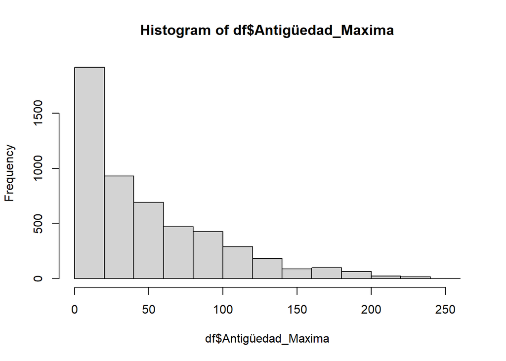

```r
hist(df$Antigüedad_Maxima)
```

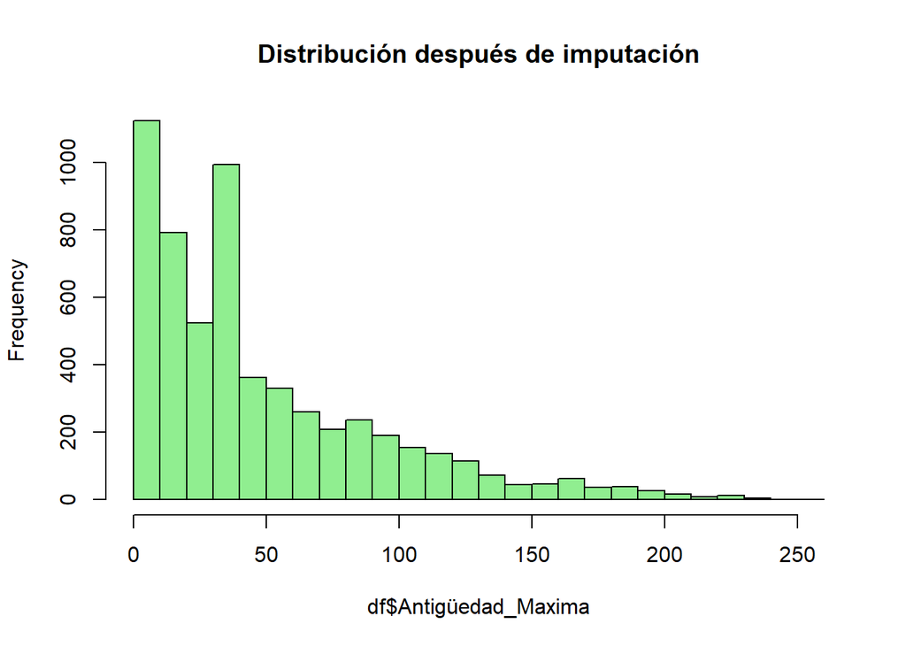

```r
# Imputar valores NA con la mediana
df$Antigüedad_Maxima <- ifelse(is.na(df$Antigüedad_Maxima),
                          median(df$Antigüedad_Maxima, na.rm = TRUE),
                                df$Antigüedad_Maxima)

# Revisar la nueva distribución
histograma<-hist(df$Antigüedad_Maxima, breaks = 30,
                 main = "Distribución después de imputación",
                 col = "lightgreen")
```

```r
histograma
```

```
## $breaks
##  [1]   0  10  20  30  40  50  60  70  80  90 100 110 120 130 140 150 160 170 180
## [20] 190 200 210 220 230 240 250 260
##
## $counts
##  [1] 1124  792  524  994  363  331  261  209  237  190  154  137  114   72   44
## [16]   46   63   37   38   27   17    9   12    4    0    1
##
## $density
##  [1] 1.937931e-02 1.365517e-02 9.034483e-03 1.713793e-02 6.258621e-03
##  [6] 5.706897e-03 4.500000e-03 3.603448e-03 4.086207e-03 3.275862e-03
## [11] 2.655172e-03 2.362069e-03 1.965517e-03 1.241379e-03 7.586207e-04
## [16] 7.931034e-04 1.086207e-03 6.379310e-04 6.551724e-04 4.655172e-04
## [21] 2.931034e-04 1.551724e-04 2.068966e-04 6.896552e-05 0.000000e+00
## [26] 1.724138e-05
##
## $mids
##  [1]   5  15  25  35  45  55  65  75  85  95 105 115 125 135 145 155 165 175 185
## [20] 195 205 215 225 235 245 255
##
## $xname
## [1] "df$Antigüedad_Maxima"
##
## $equidist
## [1] TRUE
##
## attr(,"class")
## [1] "histogram"
```

```r
# Verificar si quedan valores NA
sum(is.na(df$Antigüedad_Maxima))
```

```
## [1] 0
```

```r
summary(df$Antigüedad_Maxima)
```

```
##    Min. 1st Qu.  Median    Mean 3rd Qu.    Max.
##    0.00   14.00   34.00   48.24   68.00  255.00
```

VERIFICANDO LOS VALORES NULOS

Se verifican los valores nulos despues de los tratamientos.Si no tenemos valores nulos, se procederá a identificar si tenemos valores outliers atípicos, considerando la naturaleza de as variables y el giro de negocio de una empresa aseguradora.

```r
# tabla para verificar los valores Na
na_por_variable <- sapply(df, function(x) sum(is.na(x)))
na_por_variable
```

```
##          Cliente_ID   Antigüedad_Maxima      Nivel_Ingresos     Saldo_Pendiente
##                   0                   0                   0                   0
##  Puntaje_Morosidad1  Puntaje_Morosidad2  Puntaje_Morosidad3  Puntaje_Morosidad4
##                   0                   0                   0                   0
##  Puntaje_Morosidad5  Puntaje_Morosidad6 Saldo_Pendiente_Seg         Siniestros1
##                   0                   0                   0                   0
##         Siniestros2         Siniestros3         Siniestros4         Siniestros5
##                   0                   0                   0                   0
##         Siniestros6    Estado_Siniestro
##                   0                   0
```

# IDENTIFICACIÓN DE LOS VALORES ATÍPICOS

MÉTODO DE IDENTIFICACIÓN DE BOXPLOT

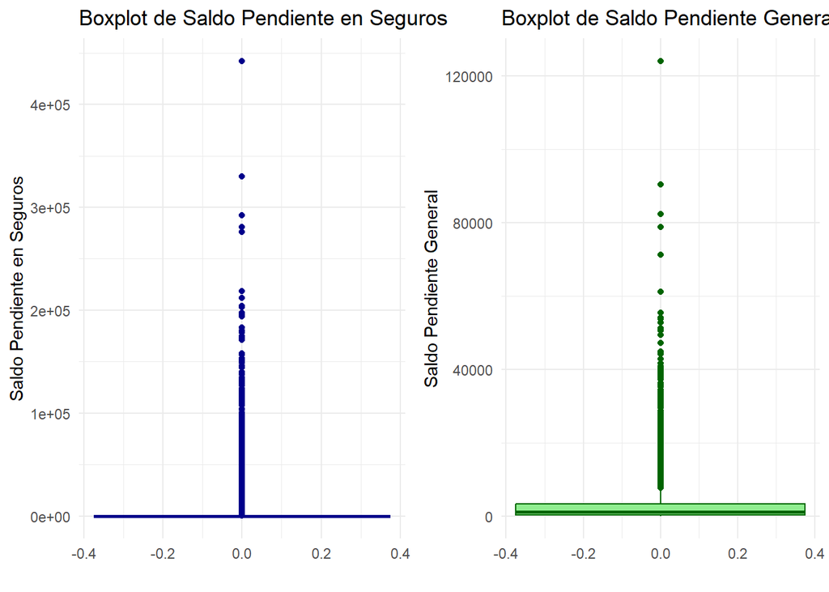

```r
# Saldo pendiente del los asegurados y del seguro
# Crear boxplot para Saldo_Pendiente_Seg
boxplot_saldo_seg <- ggplot(df, aes(y = Saldo_Pendiente_Seg)) +
  geom_boxplot(fill = "lightblue", color = "darkblue") +
  labs(title = "Boxplot de Saldo Pendiente en Seguros",
       y = "Saldo Pendiente en Seguros",x = "") +
  theme_minimal()
# Crear boxplot para Saldo_Pendiente
boxplot_saldo <- ggplot(df, aes(y = Saldo_Pendiente)) +
  geom_boxplot(fill = "lightgreen", color = "darkgreen") +
  labs(title = "Boxplot de Saldo Pendiente General",
       y = "Saldo Pendiente General", x = "") +
  theme_minimal()
# Mostrar ambos gráficos juntos
grid.arrange(boxplot_saldo_seg, boxplot_saldo, ncol = 2)
```

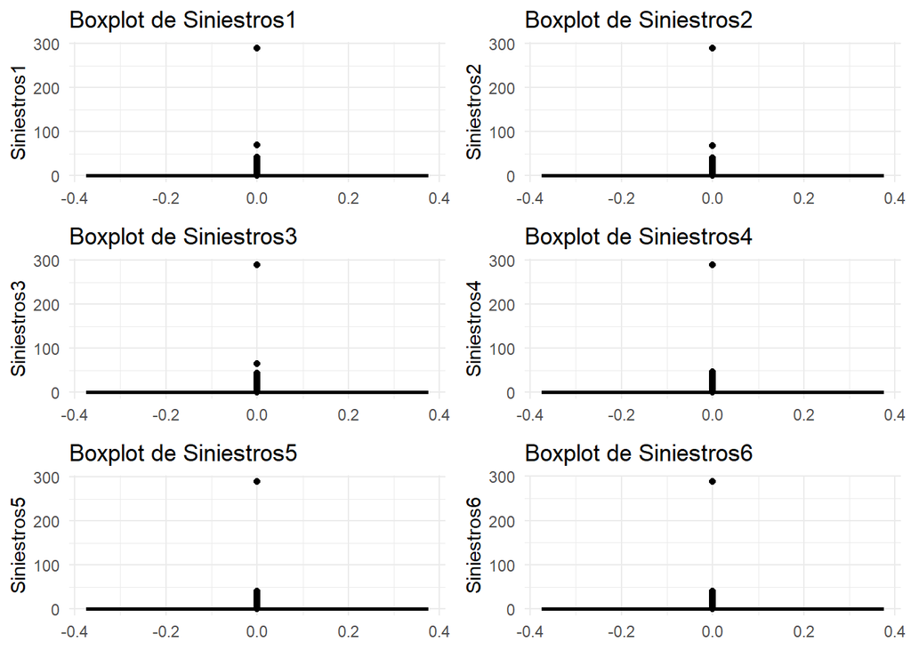

```r
# valores atipicos en siniestros
# Lista de variables
siniestros <- c("Siniestros1", "Siniestros2", "Siniestros3", "Siniestros4", "Siniestros5", "Siniestros6")
# Crear una lista para almacenar los gráficos
graficos <- list()
colores <- c("red", "blue", "green", "purple", "orange", "brown")

# Generar los gráficos de bigotes
for (i in seq_along(siniestros)) {
  graficos[[i]] <- ggplot(df, aes_string(y = siniestros[i])) +
    geom_boxplot(fill = colores[i], color = "black", outlier.color =     "black", outlier.size = 1.5) +
    labs(title = paste("Boxplot de", siniestros[i]), y = siniestros[i]) +
    theme_minimal()}
# Combinar los gráficos en un solo objeto usando gridExtra
grafico_combinado <- grid.arrange(grobs = graficos, ncol = 2)
```

```r
grafico_combinado
```

```r
summary(df$Siniestros1)
```

```
##     Min.  1st Qu.   Median     Mean  3rd Qu.     Max.
##   0.0000   0.0000   0.0000   0.7838   0.0000 289.0000
```

```r
summary(df$Siniestros2)
```

```
##    Min. 1st Qu.  Median    Mean 3rd Qu.    Max.
##   0.000   0.000   0.000   0.696   0.000 289.000
```

```r
summary(df$Siniestros3)
```

```
##     Min.  1st Qu.   Median     Mean  3rd Qu.     Max.
##   0.0000   0.0000   0.0000   0.6459   0.0000 289.0000
```

```r
summary(df$Siniestros4)
```

```
##     Min.  1st Qu.   Median     Mean  3rd Qu.     Max.
##   0.0000   0.0000   0.0000   0.5943   0.0000 289.0000
```

```r
summary(df$Siniestros5)
```

```
##     Min.  1st Qu.   Median     Mean  3rd Qu.     Max.
##   0.0000   0.0000   0.0000   0.5457   0.0000 289.0000
```

```r
summary(df$Siniestros6)
```

```
##     Min.  1st Qu.   Median     Mean  3rd Qu.     Max.
##   0.0000   0.0000   0.0000   0.5045   0.0000 288.0000
```

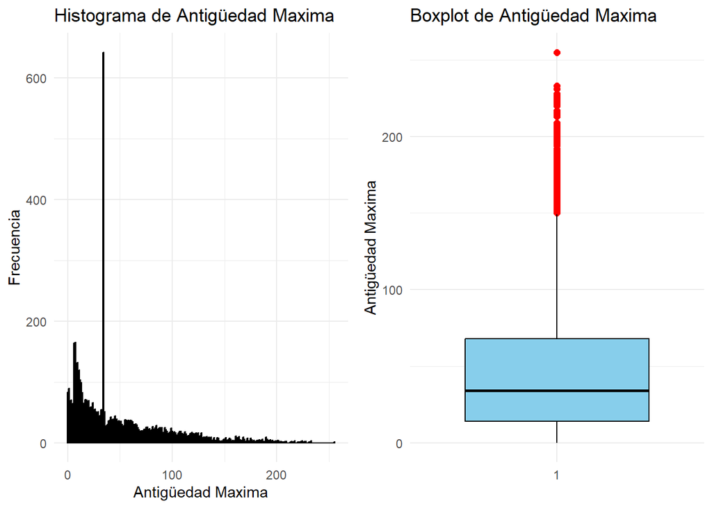

```r
# ANTIGUEDAD MÁXIMA

histograma <- ggplot(df, aes(x = Antigüedad_Maxima)) +
  geom_histogram(binwidth = 1, fill = "skyblue", color = "black", alpha = 0.7) +
  labs(title = "Histograma de Antigüedad Maxima", x = "Antigüedad Maxima",
       y = "Frecuencia") + theme_minimal()

boxplot <- ggplot(df, aes(x = factor(1), y = Antigüedad_Maxima)) +
  geom_boxplot(outlier.colour = "red", outlier.size = 2, fill = "skyblue", color = "black") +  labs(title = "Boxplot de Antigüedad Maxima", x = "",
y = "Antigüedad Maxima") + theme_minimal()

grid.arrange(histograma, boxplot, ncol = 2)
```

```r
summary(df$Antigüedad_Maxima)
```

```
##    Min. 1st Qu.  Median    Mean 3rd Qu.    Max.
##    0.00   14.00   34.00   48.24   68.00  255.00
```

# VALORES ATÍPICOS: RANGO INTERCUARTIL

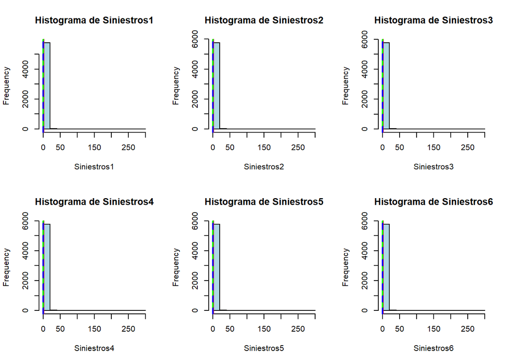

```r
# Lista de las variables
siniestros <- c("Siniestros1", "Siniestros2", "Siniestros3", "Siniestros4", "Siniestros5", "Siniestros6")

# Configurar los gráficos en una sola fila
par(mfrow=c(2,3))

# Graficar histogramas para cada variable
for (var in siniestros) {
  hist(df[[var]], main=paste("Histograma de", var), xlab=var, col="lightblue", border="black")

  # Añadir línea de media
  abline(v=mean(df[[var]], na.rm=TRUE), col="red", lwd=2)

  # Añadir línea de mediana
  abline(v=median(df[[var]], na.rm=TRUE), col="green", lwd=2)

  # Añadir líneas para los outliers (Q1 - 1.5*IQR y Q3 + 1.5*IQR)
  Q1 <- quantile(df[[var]], 0.25, na.rm=TRUE)
  Q3 <- quantile(df[[var]], 0.75, na.rm=TRUE)
  IQR <- Q3 - Q1
  outlier_lower <- Q1 - 1.5 * IQR
  outlier_upper <- Q3 + 1.5 * IQR

  abline(v=outlier_lower, col="blue", lwd=2, lty=2)
  abline(v=outlier_upper, col="blue", lwd=2, lty=2)}
```

```r
histograma1<-hist(df$Antigüedad_Maxima, breaks = 30,
                 main = "Distribución Antiguedad Máxima",
                 col = "lightgreen")

histograma2<-hist(df$Saldo_Pendiente_Seg, breaks = 30,
                 main = "Saldo pendiente en el seguro",
                 col = "lightgreen")

histograma3<-hist(df$Saldo_Pendiente, breaks = 30,
                 main = "Saldo pendiente del los clientes con el seguro",
                 col = "lightgreen")

histograma1
```

```
## $breaks
##  [1]   0  10  20  30  40  50  60  70  80  90 100 110 120 130 140 150 160 170 180
## [20] 190 200 210 220 230 240 250 260
##
## $counts
##  [1] 1124  792  524  994  363  331  261  209  237  190  154  137  114   72   44
## [16]   46   63   37   38   27   17    9   12    4    0    1
##
## $density
##  [1] 1.937931e-02 1.365517e-02 9.034483e-03 1.713793e-02 6.258621e-03
##  [6] 5.706897e-03 4.500000e-03 3.603448e-03 4.086207e-03 3.275862e-03
## [11] 2.655172e-03 2.362069e-03 1.965517e-03 1.241379e-03 7.586207e-04
## [16] 7.931034e-04 1.086207e-03 6.379310e-04 6.551724e-04 4.655172e-04
## [21] 2.931034e-04 1.551724e-04 2.068966e-04 6.896552e-05 0.000000e+00
## [26] 1.724138e-05
##
## $mids
##  [1]   5  15  25  35  45  55  65  75  85  95 105 115 125 135 145 155 165 175 185
## [20] 195 205 215 225 235 245 255
##
## $xname
## [1] "df$Antigüedad_Maxima"
##
## $equidist
## [1] TRUE
##
## attr(,"class")
## [1] "histogram"
```

```r
histograma2
```

```
## $breaks
##  [1]      0  20000  40000  60000  80000 100000 120000 140000 160000 180000
## [11] 200000 220000 240000 260000 280000 300000 320000 340000 360000 380000
## [21] 400000 420000 440000 460000
##
## $counts
##  [1] 5399  108  124   70   29   19   19    8    9    6    4    0    0    1    2
## [16]    0    1    0    0    0    0    0    1
##
## $density
##  [1] 4.654310e-05 9.310345e-07 1.068966e-06 6.034483e-07 2.500000e-07
##  [6] 1.637931e-07 1.637931e-07 6.896552e-08 7.758621e-08 5.172414e-08
## [11] 3.448276e-08 0.000000e+00 0.000000e+00 8.620690e-09 1.724138e-08
## [16] 0.000000e+00 8.620690e-09 0.000000e+00 0.000000e+00 0.000000e+00
## [21] 0.000000e+00 0.000000e+00 8.620690e-09
##
## $mids
##  [1]  10000  30000  50000  70000  90000 110000 130000 150000 170000 190000
## [11] 210000 230000 250000 270000 290000 310000 330000 350000 370000 390000
## [21] 410000 430000 450000
##
## $xname
## [1] "df$Saldo_Pendiente_Seg"
##
## $equidist
## [1] TRUE
##
## attr(,"class")
## [1] "histogram"
```

[output not shown]

[figure not shown]

```r
histograma3
```

## TRATAMIENTO DE LOS VALORES OUTLIERS

Se procederá al tratamiento segun la naturaleza que produjo el valor outlier en cada variables, es decir podrian tener orígenes distintos que prodrian ser organización en el llenado de la base de datos, error de digitación, etc. Así mismo se tendrá consideracion en que algunas variables si pueden tener valores altos que prodrían considerarse outliers, sin embargo no lo sería del todo, y que puedan requerir un suavizamiento.

# TRATAMIENTO DE LOS OUTLIERS DE LA VARIABLE ANTIGUEDA MAXIMA

```r
# Calcular los cuartiles y el rango intercuartil (IQR)
Q1 <- quantile(df$Antigüedad_Maxima, 0.25, na.rm = TRUE)
Q3 <- quantile(df$Antigüedad_Maxima, 0.75, na.rm = TRUE)
IQR_value <- IQR(df$Antigüedad_Maxima, na.rm = TRUE)

# Definir los límites inferior y superior para los valores atípicos
limite_inferior <- Q1 - 1.5 * IQR_value
limite_superior <- Q3 + 1.5 * IQR_value

# Sustituir los valores atípicos por el límite inferior o superior
df$Antigüedad_Maxima_ajustada <- ifelse(df$Antigüedad_Maxima < limite_inferior, limite_inferior,
                                        ifelse(df$Antigüedad_Maxima > limite_superior, limite_superior, df$Antigüedad_Maxima))

# Verificar los resultados
summary(df$Antigüedad_Maxima_ajustada)
```

```
##    Min. 1st Qu.  Median    Mean 3rd Qu.    Max.
##    0.00   14.00   34.00   46.91   68.00  149.00
```

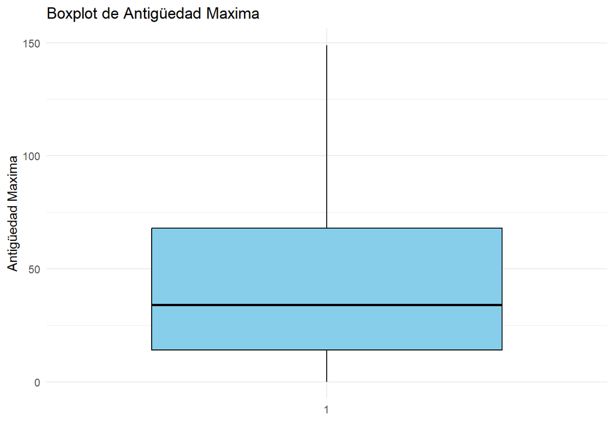

```r
ggplot(df, aes(x = factor(1), y = Antigüedad_Maxima_ajustada)) +
  geom_boxplot(outlier.colour = "red", outlier.size = 2, fill = "skyblue", color = "black") +  labs(title = "Boxplot de Antigüedad Maxima", x = "",
y = "Antigüedad Maxima") + theme_minimal()
```

```r
sum(df$Antiguedad_Maxima_ajustada == 0, na.rm = TRUE)
```

```
## [1] 0
```

```r
sum(is.na(df$Antigüedad_Maxima_ajustada))
```

```
## [1] 0
```

# TRATAMIENTO DE LOS OUTLIERS DE SINIESTROS

```r
# CREAREMOS UNA TABLA DE ESTADISTICAS DESCRIPTIVAS
# Definir las columnas de interés
columnas_siniestros <- c("Siniestros1", "Siniestros2", "Siniestros3", "Siniestros4", "Siniestros5", "Siniestros6")

# Crear una lista vacía para almacenar las estadísticas
estadisticas <- list()

# Calcular las estadísticas en un bucle
for (columna in columnas_siniestros) {
  # Calcular las estadísticas para cada columna
  min_valor <- min(df[[columna]], na.rm = TRUE)
  max_valor <- max(df[[columna]], na.rm = TRUE)
  media_valor <- mean(df[[columna]], na.rm = TRUE)
  mediana_valor <- median(df[[columna]], na.rm = TRUE)

  # Almacenar las estadísticas en la lista
  estadisticas[[columna]] <- c(Mínimo = min_valor, Máximo = max_valor, Media = media_valor, Mediana = mediana_valor)
}

# Convertir la lista en un dataframe para una tabla más legible
tabla_estadisticas <- as.data.frame(do.call(rbind, estadisticas))

# Ver la tabla de estadísticas
tabla_estadisticas
```

```
##             Mínimo Máximo     Media Mediana
## Siniestros1      0    289 0.7837931       0
## Siniestros2      0    289 0.6960345       0
## Siniestros3      0    289 0.6458621       0
## Siniestros4      0    289 0.5943103       0
## Siniestros5      0    289 0.5456897       0
## Siniestros6      0    288 0.5044828       0
```

```r
library(DescTools)
# Aplicar winsorización con DescTools
for (col in c("Siniestros1", "Siniestros2", "Siniestros3", "Siniestros4", "Siniestros5", "Siniestros6")) {
  # Winsorizar la columna con los valores por defecto (1% y 99%)
  df[[col]] <- Winsorize(df[[col]])}
# Verificar los cambios
summary(df[, c("Siniestros1", "Siniestros2", "Siniestros3", "Siniestros4", "Siniestros5", "Siniestros6")])
```

```
##   Siniestros1      Siniestros2      Siniestros3     Siniestros4
##  Min.   :0.0000   Min.   :0.0000   Min.   :0.000   Min.   :0.0000
##  1st Qu.:0.0000   1st Qu.:0.0000   1st Qu.:0.000   1st Qu.:0.0000
##  Median :0.0000   Median :0.0000   Median :0.000   Median :0.0000
##  Mean   :0.4022   Mean   :0.3157   Mean   :0.299   Mean   :0.2292
##  3rd Qu.:0.0000   3rd Qu.:0.0000   3rd Qu.:0.000   3rd Qu.:0.0000
##  Max.   :4.0000   Max.   :3.0000   Max.   :3.000   Max.   :2.0500
##   Siniestros5      Siniestros6
##  Min.   :0.0000   Min.   :0.0000
##  1st Qu.:0.0000   1st Qu.:0.0000
##  Median :0.0000   Median :0.0000
##  Mean   :0.2119   Mean   :0.1974
##  3rd Qu.:0.0000   3rd Qu.:0.0000
##  Max.   :2.0000   Max.   :2.0000
```

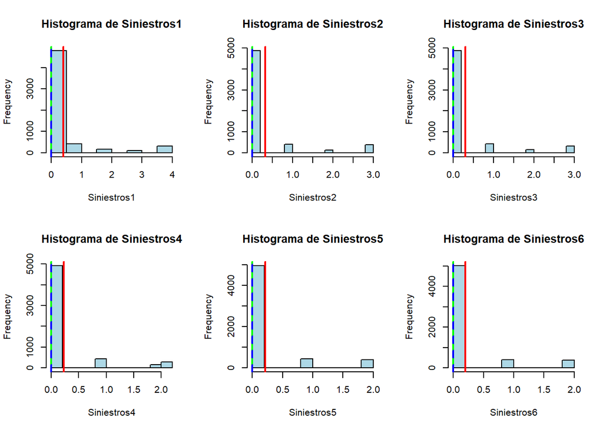

```r
# Gráfico respectivo
# Lista de las variables
siniestros <- c("Siniestros1", "Siniestros2", "Siniestros3", "Siniestros4", "Siniestros5", "Siniestros6")

# Configurar los gráficos en una sola fila
par(mfrow=c(2,3))

# Graficar histogramas para cada variable
for (var in siniestros) {
  hist(df[[var]], main=paste("Histograma de", var), xlab=var, col="lightblue", border="black")

  # Añadir línea de media
  abline(v=mean(df[[var]], na.rm=TRUE), col="red", lwd=2)

  # Añadir línea de mediana
  abline(v=median(df[[var]], na.rm=TRUE), col="green", lwd=2)

  # Añadir líneas para los outliers (Q1 - 1.5*IQR y Q3 + 1.5*IQR)
  Q1 <- quantile(df[[var]], 0.25, na.rm=TRUE)
  Q3 <- quantile(df[[var]], 0.75, na.rm=TRUE)
  IQR <- Q3 - Q1
  outlier_lower <- Q1 - 1.5 * IQR
  outlier_upper <- Q3 + 1.5 * IQR

  abline(v=outlier_lower, col="blue", lwd=2, lty=2)
  abline(v=outlier_upper, col="blue", lwd=2, lty=2)}
```

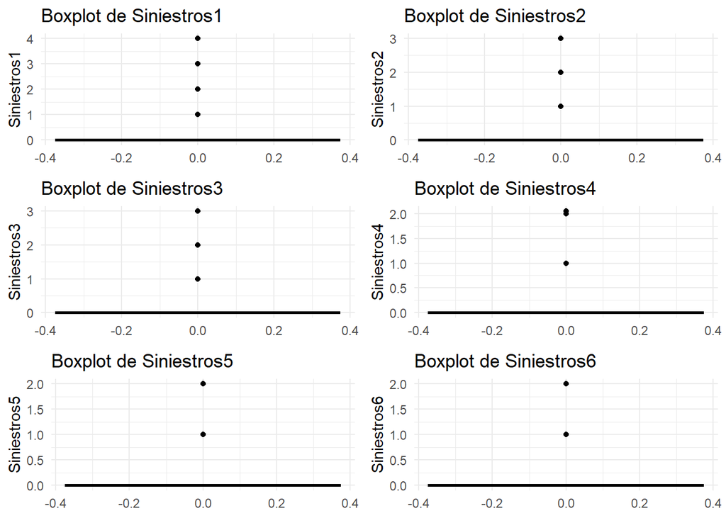

```r
# gráfico de bigotes

siniestros <- c("Siniestros1", "Siniestros2", "Siniestros3", "Siniestros4", "Siniestros5", "Siniestros6")
graficos <- list()
colores <- c("red", "blue", "green", "purple", "orange", "brown")
for (i in seq_along(siniestros)) {
  graficos[[i]] <- ggplot(df, aes_string(y = siniestros[i])) +
    geom_boxplot(fill = colores[i], color = "black", outlier.color =     "black", outlier.size = 1.5) +
    labs(title = paste("Boxplot de", siniestros[i]),
         y = siniestros[i]) +theme_minimal()}
# Combinar los gráficos en un solo objeto usando gridExtra
grafico_combinado <- grid.arrange(grobs = graficos, ncol = 2)
```

# TRATAMIENTO DE LOS VALORES OUTLIERS DE SALDO PENDIENTE DEL SEGURO

Se observo que en saldo pendiente, es decir el dinero que deben los clientes a la aseguradora debe estar relacionada a los puntajes de morosidad, por ejemplo si un cliente no tienen deuda en las tasas de morosidad es lógico que no tenga saldo pendite con la aseguradora, bajo esta lógica se va a tratar los valores que no cumplan con este requisito necesario. Por otro lado, sucede que las personas que no tubieron ningún tipo de siniestro, no deberia de cobrar ningun saldo por parte de la empresa aseguradora, por ello, si un cliente no tubo ningún accidente o siniestro no tienen saldo a cobrar en la aseguradora, por lo tanto bajo esa condición el saldo pendiente de la aseguradora sería cero.

```r
# Parte uno: Saldo pendiente del cliente con la aseguradora
df <- df %>%
  mutate(Saldo_Pendiente = if_else(
    Puntaje_Morosidad1 == "Sin deuda" &
    Puntaje_Morosidad2 == "Sin deuda" &
    Puntaje_Morosidad3 == "Sin deuda" &
    Puntaje_Morosidad4 == "Sin deuda" &
    Puntaje_Morosidad5 == "Sin deuda" &
    Puntaje_Morosidad6 == "Sin deuda",
    0.00,
    Saldo_Pendiente
  ))

# Verificar los resultados
# Redondear los valores de Saldo_Pendiente a dos decimales
df$Saldo_Pendiente <- round(df$Saldo_Pendiente, 2)
summary(df$Saldo_Pendiente)
```

```
##     Min.  1st Qu.   Median     Mean  3rd Qu.     Max.
##      0.0      0.0      0.0    804.5      0.0 124102.1
```

```r
sum(is.na(df$Saldo_Pendiente))
```

```
## [1] 0
```

```r
sum(df$Saldo_Pendiente == 0, na.rm = TRUE)  # Cantidad de ceros
```

```
## [1] 4528
```

```r
head(df)
```

```
##   Cliente_ID Antigüedad_Maxima Nivel_Ingresos Saldo_Pendiente
## 1        185                44              1               0
## 2        238                79              1               0
## 3        346               102              1               0
## 4        460                34              1               0
## 5        549               109              1               0
## 6        559               183              1               0
##   Puntaje_Morosidad1 Puntaje_Morosidad2 Puntaje_Morosidad3 Puntaje_Morosidad4
## 1          Sin deuda          Sin deuda          Sin deuda          Sin deuda
## 2          Sin deuda          Sin deuda          Sin deuda          Sin deuda
## 3          Sin deuda          Sin deuda          Sin deuda          Sin deuda
## 4          Sin deuda          Sin deuda          Sin deuda          Sin deuda
## 5          Sin deuda          Sin deuda          Sin deuda          Sin deuda
## 6          Sin deuda          Sin deuda          Sin deuda          Sin deuda
##   Puntaje_Morosidad5 Puntaje_Morosidad6 Saldo_Pendiente_Seg Siniestros1
```

[output cut: 20 more lines]

```r
# Parte2: Saldo pendiente de la aseguradora con sus cliente accidentados

df$Siniestros4 <- round(df$Siniestros4, 0)
df <- df %>%
  mutate(Saldo_Pendiente_Seg = if_else( Siniestros1 ==0 &
     Siniestros2 == 0 &
     Siniestros3 == 0 &
     Siniestros4 == 0 &
     Siniestros5 == 0 &
     Siniestros6 == 0 ,
     0.00, Saldo_Pendiente_Seg ))

# Verificar los resultados
# Redondear los valores de Saldo_Pendiente a dos decimales
df$Saldo_Pendiente_Seg <- round(df$Saldo_Pendiente_Seg, 2)
summary(df$Saldo_Pendiente_Seg)
```

```
##     Min.  1st Qu.   Median     Mean  3rd Qu.     Max.
##      0.0      0.0      0.0    712.2      0.0 218543.8
```

```r
sum(is.na(df$Saldo_Pendiente_Seg))
```

```
## [1] 0
```

GRÁFICO DE BOX PLOT: OUTLIERS DE LOS SALDOS

Se realizó un tratamiento específico de los datos, sin embargo todavia se necesita evaluar los siguientes escenarios de valores atípicos: 1. Valores outliers fuera del rango intercuartil. 2.Valores de saldo pendientes de la aseguradora con sus clientes y que tubieron varios siniestro y que figuran con saldos ceros. 3.Considerar que podrian haber valores altos que no son outiers dado que los accidentes dependiendo de las gravedades y sus tipos y coberturas tendrán desembolsos por parte de la aseguradora que podría sser elevado, con lo cual se podria admitir valores elevados o suavizar dichos valores con un método adecuado.

En esta parte antes de analizar dicha situaciones, se van a visualizar el gráfico de box plot.

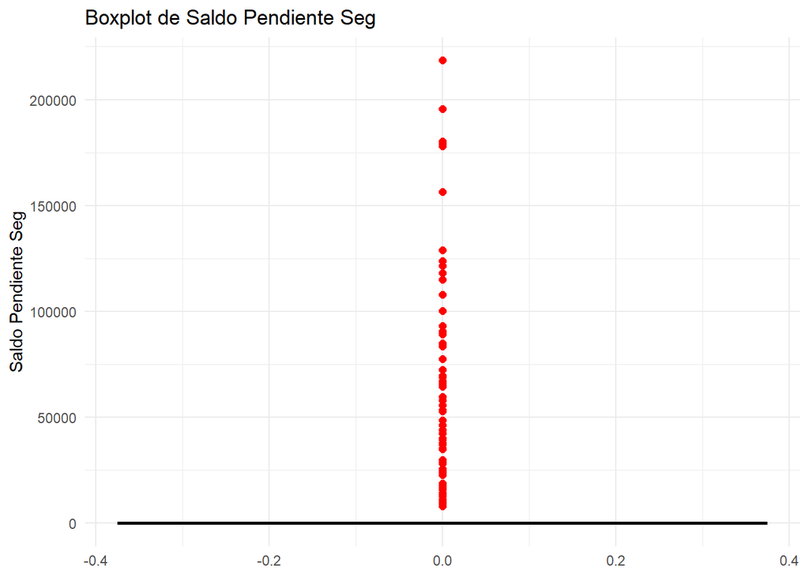

```r
library(ggplot2)
# Boxplot de Saldo_Pendiente_Seg
ggplot(df, aes(y = Saldo_Pendiente_Seg)) +
  geom_boxplot(fill = "skyblue", color = "black", outlier.colour = "red", outlier.size = 2) +
  labs(title = "Boxplot de Saldo Pendiente Seg", y = "Saldo Pendiente Seg") +
  theme_minimal()
```

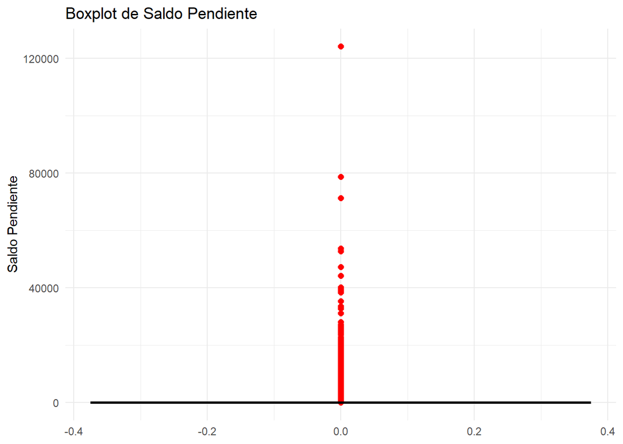

```r
# Boxplot de Saldo_Pendiente
ggplot(df, aes(y = Saldo_Pendiente)) +
  geom_boxplot(fill = "lightgreen", color = "black", outlier.colour = "red", outlier.size = 2) +
  labs(title = "Boxplot de Saldo Pendiente", y = "Saldo Pendiente") +
  theme_minimal()
```

# TRATAMIENTO DE VALORES OUTLIERS

MÉTODO ROBUSTO:

Dada la relación que puede existir entre las tasas de morosidad,mese de antiguedad con el saldo que deben los clientes se podria predecir los valores de estas y dar tratamiento a los outliers,sin embargo hay que recordar que hay muchos ceros en la variable,asi como la mayoría de los valores predictivos son categóricos, su capacidad para identificar y manejar esos outliers en la respuesta puede verse limitada,lo cual podría afectar las convergencia, predicciones y el tratamiento.

MÉTODO DE RPART: ARBO DE DESICIONES

El uso de árboles de decisión como rpart para tratar valores atípicos puede ser una buena opción si: -Tus datos no siguen una distribución normal. -No necesitas hacer suposiciones sobre la forma de los datos. -Tienes una mezcla de variables numéricas y categóricas. -Deseas un modelo robusto que no se vea excesivamente afectado por los outliers. -Sin embargo, es importante recordar que los árboles de decisión no eliminan los outliers, sino que los pueden segmentar de manera que su impacto en el modelo general sea mínimo. Puede ser una opción mejor que simplemente reemplazar los outliers con valores como la media, mediana o moda, o incluso con valores de un rango intercuartil (IQR),que casi siempre ponen un único valor en las observaciones consideradas como outliers.

## TRATAMIENTO DE LOS SALDOS PENDIENTES DE LA ASEGURADORA CON SUS CLIENTES

El tratamiento de los datos de una distirbución sesgada a la derecha y con distribución normal por la median, media en este caso sería colocar puro cero u otro vlaor igual para todo los outliers, lo cual podria ser un error, dado que personas que tubieron por lo menos un siniestro en su vida a lo largo de contrato de seguros deberian de tener un saldo a cobrar ,o personas que tubieron mas de dos o tres siniestros deberian de cobrar mas o mnoes cantidd de la media, es decir el saldo pendiente de la aseguradora con su clientes debe ser diferente de cero y en distintas cantidades, segun los tipos de siniestros y sus coberturas

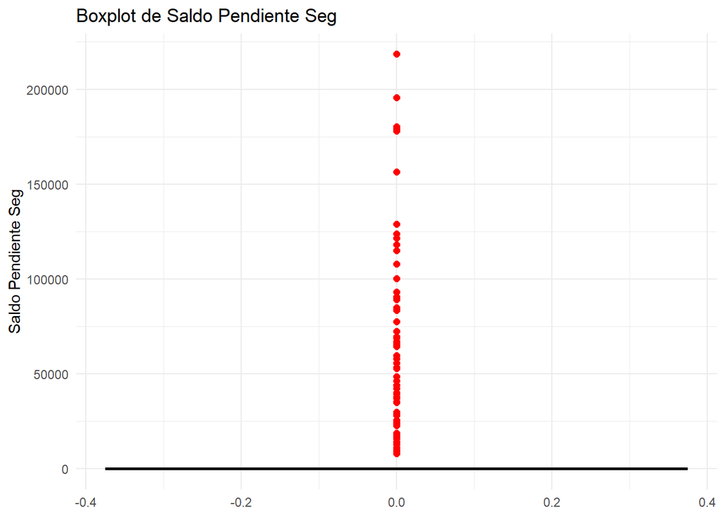

```r
# Boxplot de Saldo_Pendiente_Seg
ggplot(df, aes(y = Saldo_Pendiente_Seg)) +
  geom_boxplot(fill = "skyblue", color = "black", outlier.colour = "red", outlier.size = 2) +
  labs(title = "Boxplot de Saldo Pendiente Seg", y = "Saldo Pendiente Seg") +
  theme_minimal()
```

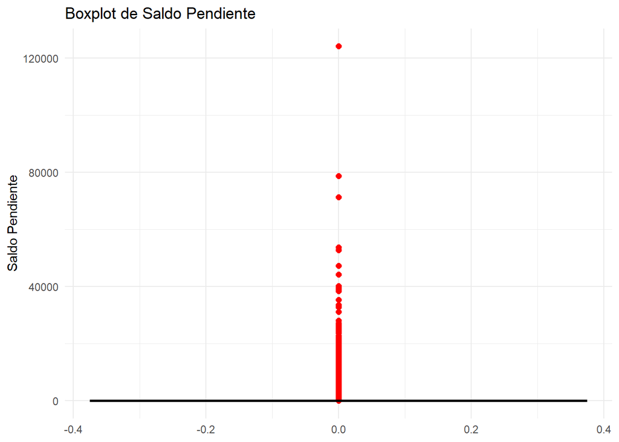

```r
# Boxplot de Saldo_Pendiente
ggplot(df, aes(y = Saldo_Pendiente)) +
  geom_boxplot(fill = "lightgreen", color = "black", outlier.colour = "red", outlier.size = 2) +
  labs(title = "Boxplot de Saldo Pendiente", y = "Saldo Pendiente") +
  theme_minimal()
```

DECISICIÓN DE LA IMPUTACIÓN CON WINSCORIZACIÓN:

```r
# Calcular los percentiles 1% y 99% de la variable Saldo_Pendiente
percentil_1 <- quantile(df$Saldo_Pendiente_Seg, 0.01, na.rm = TRUE)
percentil_99 <- quantile(df$Saldo_Pendiente_Seg, 0.99, na.rm = TRUE)

# Winsorización: Reemplazar los valores fuera de estos límites
df$Saldo_Pendiente_Seg_W <- df$Saldo_Pendiente_Seg

# Reemplazar los valores menores al percentil 1 por el valor del percentil 1
df$Saldo_Pendiente_Seg_W[df$Saldo_Pendiente_Seg < percentil_1] <- percentil_1

# Reemplazar los valores mayores al percentil 99 por el valor del percentil 99
df$Saldo_Pendiente_Seg_W[df$Saldo_Pendiente_Seg > percentil_99] <- percentil_99
# Aplicar reglas lógicas para corregir los valores
# Si hay algún siniestro y el saldo pendiente es cero
df$Saldo_Pendiente_Seg_W <- ifelse(df$Saldo_Pendiente_Seg_W == 0 & (df$Siniestros1 != 0 |df$Siniestros2 != 0 |  df$Siniestros3 != 0 | df$Siniestros4 != 0 |df$Siniestros5 != 0 | df$Siniestros6 != 0),  712,   df$Saldo_Pendiente_Seg_W)
# Ver los primeros registros después de la corrección
summary(df$Saldo_Pendiente_Seg_W)
```

```
##    Min. 1st Qu.  Median    Mean 3rd Qu.    Max.
##     0.0     0.0     0.0   292.9   712.0 11193.7
```

# TRATAMIENTO DE SALDO PENDIENTE DE LOS CLIENTES CON EL SEGURO

```r
# Calcular los percentiles 1% y 99% de la variable Saldo_Pendiente
percentil_1 <- quantile(df$Saldo_Pendiente, 0.01, na.rm = TRUE)
percentil_99 <- quantile(df$Saldo_Pendiente, 0.99, na.rm = TRUE)

# Winsorización: Reemplazar los valores fuera de estos límites
df$Saldo_Pendiente_Winsorized <- df$Saldo_Pendiente

# Reemplazar los valores menores al percentil 1 por el valor del percentil 1
df$Saldo_Pendiente_Winsorized[df$Saldo_Pendiente < percentil_1] <- percentil_1

# Reemplazar los valores mayores al percentil 99 por el valor del percentil 99
df$Saldo_Pendiente_Winsorized[df$Saldo_Pendiente > percentil_99] <- percentil_99

# Ver los primeros registros para confirmar el cambio
summary(df$Saldo_Pendiente_Winsorized)
```

```
##    Min. 1st Qu.  Median    Mean 3rd Qu.    Max.
##     0.0     0.0     0.0   673.6     0.0 15332.5
```

# GRÁFICOS:

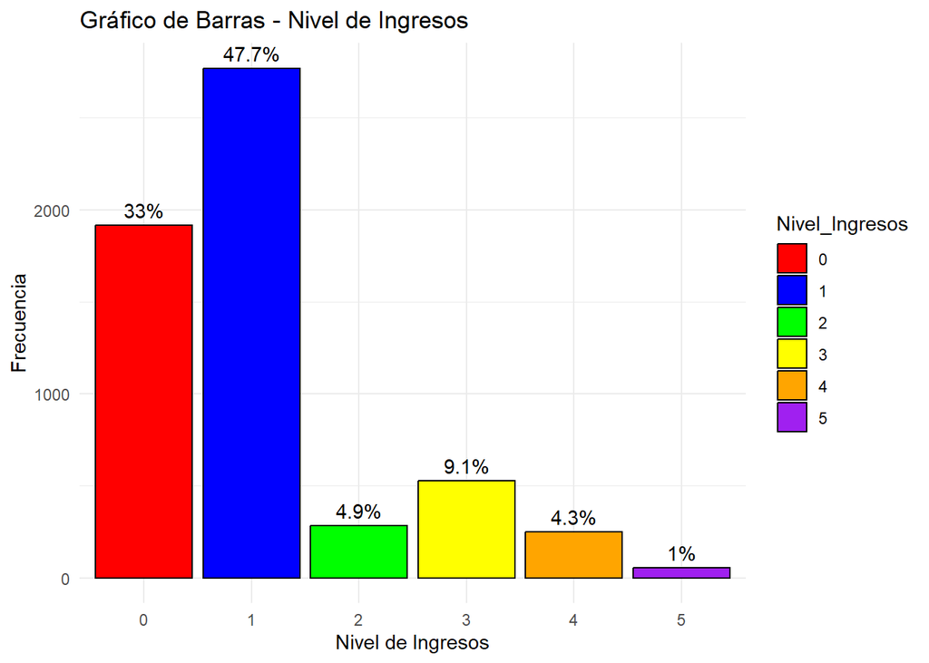

```r
# Calcular frecuencias
frecuencias <- df %>%
  group_by(Nivel_Ingresos) %>%
  summarise(Frecuencia = n()) %>%
  mutate(Porcentaje = Frecuencia / sum(Frecuencia) * 100)

# Crear gráfico de barras con porcentajes
grafico_barras <- ggplot(frecuencias, aes(x = Nivel_Ingresos, y = Frecuencia, fill = Nivel_Ingresos)) +
  geom_bar(stat = "identity", color = "black") +
  scale_fill_manual(values = c("red", "blue", "green", "yellow", "orange", "purple")) +  # Colores personalizados
  geom_text(aes(label = paste0(round(Porcentaje, 1), "%")), vjust = -0.5) +  # Agregar etiquetas con porcentajes
  labs(title = "Gráfico de Barras - Nivel de Ingresos", x = "Nivel de Ingresos", y = "Frecuencia") +
  theme_minimal()
# Mostrar gráfico de barras
print(grafico_barras)
```

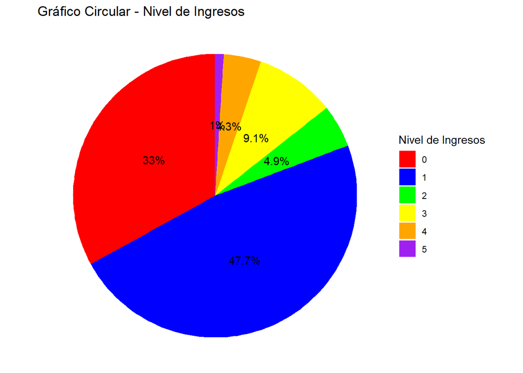

```r
# Crear gráfico circular con porcentajes
grafico_circular <- ggplot(frecuencias, aes(x = "", y = Frecuencia, fill = factor(Nivel_Ingresos))) +
  geom_bar(stat = "identity", width = 1) +
  coord_polar(theta = "y") +
  scale_fill_manual(values = c("red", "blue", "green", "yellow", "orange", "purple")) +  # Colores personalizados
  geom_text(aes(label = paste0(round(Porcentaje, 1), "%")), position = position_stack(vjust = 0.5)) +  # Etiquetas con porcentajes
  labs(title = "Gráfico Circular - Nivel de Ingresos", fill = "Nivel de Ingresos") +
  theme_void()
# Mostrar gráfico circular
print(grafico_circular)
```

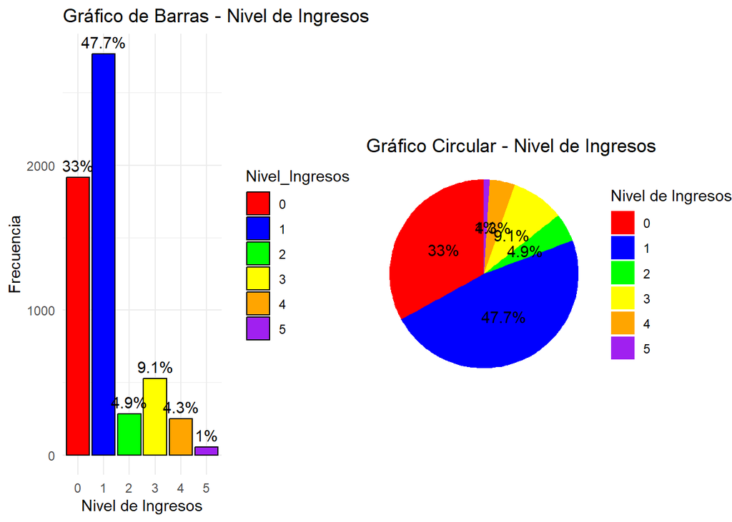

```r
# Unir ambos gráficos en un solo objeto (dos gráficos en una fila)
grid.arrange(grafico_barras, grafico_circular, ncol = 2)
```

# TABLAS SIMPLE Y DE CONTINGENCIA:

Se realizará las tablas de distribución de frecuencias y las repectivas tablas de contingencia que nos bridarán información de nuestra data final.

```r
# Tabla de contingencia entre Nivel_Ingresos y Estado_Siniestro en porcentajes (por filas)
prop.table(table(df$Nivel_Ingresos, df$Estado_Siniestro), margin = 1) * 100
```

```
##
##             no         si
##   0  87.049608  12.950392
##   1  92.452149   7.547851
##   2  93.286219   6.713781
##   3  97.920605   2.079395
##   4  96.370968   3.629032
##   5 100.000000   0.000000
```

```r
# Tabla de contingencia entre Puntaje_Morosidad1 y Estado_Siniestro en porcentajes (por filas)
prop.table(table(df$Puntaje_Morosidad1, df$Estado_Siniestro), margin = 1) * 100
```

```
##
##                        no         si
##   Sin deuda     96.006204   3.993796
##   1-29 días     68.870523  31.129477
##   30-59 días    32.283465  67.716535
##   60-89 días    10.784314  89.215686
##   90-119 días  100.000000   0.000000
##   120-149días  100.000000   0.000000
##   150-179 días 100.000000   0.000000
```

```r
prop.table(table(df$Puntaje_Morosidad2, df$Estado_Siniestro), margin = 1) * 100
```

```
##
##                        no         si
##   Sin deuda     95.541401   4.458599
##   1-29 días     66.153846  33.846154
##   30-59 días    27.007299  72.992701
##   60-89 días    50.000000  50.000000
##   90-119 días   86.363636  13.636364
##   120-149 días  88.888889  11.111111
##   150-179 días 100.000000   0.000000
```

```r
prop.table(table(df$Puntaje_Morosidad3, df$Estado_Siniestro), margin = 1) * 100
```

```
##
##                       no        si
##   Sin deuda    95.071908  4.928092
##   1-29 días    61.675127 38.324873
##   30-59 días   45.217391 54.782609
##   60-89 días   65.909091 34.090909
##   90-119 días  80.000000 20.000000
##   120-149 días 80.000000 20.000000
##   150-179 días 50.000000 50.000000
```

```r
prop.table(table(df$Puntaje_Morosidad4, df$Estado_Siniestro), margin = 1) * 100
```

```
##
##                       no        si
##   Sin deuda    94.508835  5.491165
##   1-29 días    63.116883 36.883117
##   30-59 días   55.102041 44.897959
##   60-89 días   64.285714 35.714286
##   90-119 días  60.000000 40.000000
##   120-149 días 53.846154 46.153846
##   150-179 días 62.500000 37.500000
```

```r
prop.table(table(df$Puntaje_Morosidad5, df$Estado_Siniestro), margin = 1) * 100
```

```
##
##                       no        si
##   Sin deuda    94.112061  5.887939
##   1-29 días    70.332481 29.667519
##   30-59 días   47.916667 52.083333
##   60-89 días   55.555556 44.444444
##   90-119 días  46.666667 53.333333
##   120-149 días 70.000000 30.000000
##   150-179 días 80.000000 20.000000
```

```r
prop.table(table(df$Puntaje_Morosidad6, df$Estado_Siniestro), margin = 1) * 100
```

```
##
##                       no        si
##   Sin deuda    93.666099  6.333901
##   1-29 días    70.918367 29.081633
##   30-59 días   58.333333 41.666667
##   60-89 días   56.000000 44.000000
##   90-119 días  63.636364 36.363636
##   120-149 días 85.714286 14.285714
##   150-179 días 75.000000 25.000000
```

# ESTADÍSTICAS DESCRIPTIVAS:

Se calculará las estadísticas descriptivas de la data final.

```r
# CREANDO UNA VARIABLE DE SINIESTROS TOTALES
# Calcular el número total de siniestros como la suma de Siniestros1 a Siniestros6
df$Numero_Siniestros_Totales <- rowSums(df[, c("Siniestros1", "Siniestros2", "Siniestros3", "Siniestros4", "Siniestros5", "Siniestros6")], na.rm = TRUE)
# Crear una lista de las columnas objetivo
columnas_objetivo <- c(
    "Antigüedad_Maxima_ajustada", "Saldo_Pendiente_Winsorized",
    "Saldo_Pendiente_Seg_W","Siniestros1", "Siniestros2", "Siniestros3",
    "Siniestros4", "Siniestros5", "Siniestros6","Numero_Siniestros_Totales")
# Generar una tabla resumen
resumen <- lapply(df[columnas_objetivo], summary)
# Convertir a un data.frame legible
tabla_resumen <- do.call(rbind, resumen)
colnames(tabla_resumen) <- c("Min", "1st_Qu", "Median", "Mean", "3rd_Qu", "Max")
# Mostrar tabla
print(as.data.frame(tabla_resumen))
```

```
##                            Min 1st_Qu Median        Mean 3rd_Qu      Max
## Antigüedad_Maxima_ajustada   0     14     34  46.9106897     68   149.00
## Saldo_Pendiente_Winsorized   0      0      0 673.6362782      0 15332.46
## Saldo_Pendiente_Seg_W        0      0      0 292.9165881    712 11193.69
## Siniestros1                  0      0      0   0.4022414      0     4.00
## Siniestros2                  0      0      0   0.3156897      0     3.00
## Siniestros3                  0      0      0   0.2989655      0     3.00
## Siniestros4                  0      0      0   0.2267241      0     2.00
## Siniestros5                  0      0      0   0.2118966      0     2.00
## Siniestros6                  0      0      0   0.1974138      0     2.00
## Numero_Siniestros_Totales    0      0      0   1.6529310      1    16.00
```

# ESTADISTICA INFERENCIAL:

PRUEBA DE NORMALIDAD:

Los resultados indican con evidencia fuerte que podemos rechazar la hipótesis nula de que las variables siguen una distribución normal. Es probable que todas las variables que has probado no sigan una distribución normal.

```r
library(nortest)
# Listar las variables a probar
variables <- c("Saldo_Pendiente_Winsorized", "Saldo_Pendiente_Seg_W", "Siniestros1", "Siniestros2", "Siniestros3", "Siniestros4", "Siniestros5", "Siniestros6")

# Realizar la prueba de Kolmogorov-Smirnov para cada variable y guardar los resultados
ks_results <- lapply(variables, function(var) {
  ks_result <- ks.test(df[[var]], "pnorm", mean = mean(df[[var]], na.rm = TRUE), sd = sd(df[[var]], na.rm = TRUE))
  data.frame(
    Variable = var,
    D_Statistic = ks_result$statistic,
    P_Value = format.pval(ks_result$p.value))})
# Convertir los resultados en un solo data.frame
ks_results_df <- do.call(rbind, ks_results)
# Instalar y cargar knitr para una mejor visualización
library(knitr)
# Mostrar los resultados en formato de tabla en RStudio
kable(ks_results_df, caption = "Resultados de la Prueba de Kolmogorov-Smirnov")
```

Resultados de la Prueba de Kolmogorov-Smirnov

|  | Variable | D_Statistic | P_Value |
| --- | --- | --- | --- |
| D | Saldo_Pendiente_Winsorized | 0.4011833 | < 2.22e-16 |
| D1 | Saldo_Pendiente_Seg_W | 0.4013018 | < 2.22e-16 |
| D2 | Siniestros1 | 0.4789285 | < 2.22e-16 |
| D3 | Siniestros2 | 0.4919883 | < 2.22e-16 |
| D4 | Siniestros3 | 0.4912646 | < 2.22e-16 |
| D5 | Siniestros4 | 0.5038149 | < 2.22e-16 |
| D6 | Siniestros5 | 0.5063754 | < 2.22e-16 |
| D7 | Siniestros6 | 0.5108897 | < 2.22e-16 |

# PRUEBA DE NORMALIDAD DOS

Se requiere comprobar que las variables mencionadas anteriormente siguen una distribución no normal dado un p -valor muy inferior a cero.

```r
# Prueba de Anderson-Darling

ad_test1 <- ad.test(df$Antigüedad_Maxima_ajustada)
print("Prueba de Anderson-Darling")
```

```
## [1] "Prueba de Anderson-Darling"
```

```r
print(ad_test1)
```

```
##
##  Anderson-Darling normality test
##
## data:  df$Antigüedad_Maxima_ajustada
## A = 243.51, p-value < 2.2e-16
```

```r
ad_test1 <- ad.test(df$Saldo_Pendiente_Seg_W)
print("Prueba de Anderson-Darling")
```

```
## [1] "Prueba de Anderson-Darling"
```

```r
print(ad_test1)
```

```
##
##  Anderson-Darling normality test
##
## data:  df$Saldo_Pendiente_Seg_W
## A = 1437.5, p-value < 2.2e-16
```

```r
# Prueba Anderson-Darling
ad_test2 <- ad.test(df$Saldo_Pendiente_Winsorized)
print(ad_test2)
```

```
##
##  Anderson-Darling normality test
##
## data:  df$Saldo_Pendiente_Winsorized
## A = 1519, p-value < 2.2e-16
```

# PRUEBAS NO PARAMÉTRICAS KRUSKAL- WALLIS

Objetivo: Comparar las medianas de más de dos grupos independientes (en este caso, las 6 categorías de Nivel de Ingreso).

Respecto al resultado observado, dado que el p-valor es menor a 0.05 la prueba muestra que existen diferencias significativas entre ciertos grupos (por ejemplo, entre los grupos 0 y 1, 0 y 3, etc.), mientras que en otros pares de grupos las diferencias no son significativas (por ejemplo, entre 1 y 2, 4 y 5).

Esto sugiere que las distribuciones de Saldo_Pendiente_Winsorized son diferentes entre algunos de los grupos, pero no entre todos.

```r
library(dunn.test)
# Prueba de Kruskal-Wallis
kruskal_test <- kruskal.test(df$Saldo_Pendiente_Winsorized ~ df$Nivel_Ingresos)
kruskal_test
```

```
##
##  Kruskal-Wallis rank sum test
##
## data:  df$Saldo_Pendiente_Winsorized by df$Nivel_Ingresos
## Kruskal-Wallis chi-squared = 57.026, df = 5, p-value = 4.995e-11
```

```r
# Prueba post hoc de Dunn con corrección de Bonferroni
dunn_results <- dunn.test(df$Saldo_Pendiente_Winsorized, df$Nivel_Ingreso,
                          method = "bonferroni")
```

```
##   Kruskal-Wallis rank sum test
##
## data: x and group
## Kruskal-Wallis chi-squared = 57.0259, df = 5, p-value = 0
##
##
##                            Comparison of x by group
##                                  (Bonferroni)
## Col Mean-|
## Row Mean |          0          1          2          3          4
## ---------+-------------------------------------------------------
##        1 |   4.881025
##          |    0.0000*
##        2 |   3.510343   1.257652
##          |    0.0034*     1.0000
##        3 |   6.253684   3.416190   1.135289
##          |    0.0000*    0.0048*     1.0000
##        4 |   2.945158   0.810019  -0.285080  -1.408652
##          |    0.0242*     1.0000     1.0000     1.0000
##        5 |   3.000864   1.939318   1.253097   0.709204   1.406343
##          |    0.0202*     0.3935     1.0000     1.0000     1.0000
##
## alpha = 0.05
## Reject Ho if p <= alpha/2
```

```r
print(dunn_results)
```

```
## $chi2
## [1] 57.02595
##
## $Z
##  [1]  4.8810256  3.5103438  1.2576525  6.2536843  3.4161904  1.1352900
##  [7]  2.9451588  0.8100195 -0.2850804 -1.4086527  3.0008641  1.9393181
## [13]  1.2530977  0.7092046  1.4063431
##
## $P
##  [1] 5.276777e-07 2.237638e-04 1.042587e-01 2.004406e-10 3.175192e-04
##  [6] 1.281269e-01 1.613945e-03 2.089645e-01 3.877913e-01 7.946894e-02
## [11] 1.346073e-03 2.623131e-02 1.050851e-01 2.390988e-01 7.981113e-02
##
## $P.adjusted
##  [1] 7.915165e-06 3.356458e-03 1.000000e+00 3.006608e-09 4.762788e-03
##  [6] 1.000000e+00 2.420917e-02 1.000000e+00 1.000000e+00 1.000000e+00
## [11] 2.019110e-02 3.934696e-01 1.000000e+00 1.000000e+00 1.000000e+00
##
## $comparisons
##  [1] "0 - 1" "0 - 2" "1 - 2" "0 - 3" "1 - 3" "2 - 3" "0 - 4" "1 - 4" "2 - 4"
## [10] "3 - 4" "0 - 5" "1 - 5" "2 - 5" "3 - 5" "4 - 5"
```

# PRUEBA DE TENDENCIA DE JHONCKHERER - TERSPSTRA TEST

Dado que los niveles de Nivel_Ingreso tienen un orden lógico (por ejemplo, de menor ingreso a mayor ingreso), la prueba Jonckheere-Terpstra evalúa si existe una tendencia monótona (creciente o decreciente) en Saldo_Pendiente_Seg

Respecto al resultado, dado que p valor es muy bajo y crecano a cero, es probable que a medida que aumentan los niveles de ingresos (Nivel_Ingresos), hay una tendencia creciente o decreciente en el Saldo_Pendiente_Seg.

```r
library(DescTools)
JonckheereTerpstraTest(Saldo_Pendiente_Seg_W ~ Nivel_Ingresos, data = df)
```

```
##
##  Jonckheere-Terpstra test
##
## data:  Saldo_Pendiente_Seg_W by Nivel_Ingresos
## JT = 4819582, p-value < 2.2e-16
## alternative hypothesis: two.sided
```

# CREACIÓN DE NUEVAS VARIABLES

Sería más provechoso crear una sola variable del nivel de ingresos para simplificarlo y luego realizar pruebas de tablas de contingencia y pruebas entre variables cualitativas mas precisas.

```r
df <- df %>%
    mutate(Nivel_Ingresos_Agrupado = case_when(
        Nivel_Ingresos %in% c("0", "1") ~ "Bajo",
        Nivel_Ingresos %in% c("2", "3") ~ "Medio",
        Nivel_Ingresos %in% c("4", "5") ~ "Alto"
    ))
table(df$Nivel_Ingresos_Agrupado)
```

```
##
##  Alto  Bajo Medio
##   304  4684   812
```

# PRUEBA DE INDEPENDENCIA DE CHI CUADRADO

El test Chi-cuadrado de Pearson que evalúa la relación de independencia entre las variables categóricas. En otras palabras, está probando en este caso si el nivel de ingresos tiene alguna relación con la probabilidad de que ocurra un siniestro. De los resultados dados, con un valor p tan pequeño (1.425e-10), rechazamos la hipótesis nula y concluimos que hay una relación estadísticamente significativa entre el nivel de ingresos de los clientes y la probabilidad de que ocurran siniestro o Estado de siniestro.

```r
# Prueba de chi-cuadrado para Nivel_Ingresos vs Estado_Siniestro
chi_square_nivel_ingresos <- chisq.test(table(df$Nivel_Ingresos_Agrupado, df$Estado_Siniestro))
print(chi_square_nivel_ingresos)
```

```
##
##  Pearson's Chi-squared test
##
## data:  table(df$Nivel_Ingresos_Agrupado, df$Estado_Siniestro)
## X-squared = 45.343, df = 2, p-value = 1.425e-10
```

# PRUEBA DE LA U DE MAN-WHITNEY

```r
# Realizar la prueba de Mann-Whitney
wilcox.test(Saldo_Pendiente_Winsorized ~ Estado_Siniestro, data = df)
```

```
##
##  Wilcoxon rank sum test with continuity correction
##
## data:  Saldo_Pendiente_Winsorized by Estado_Siniestro
## W = 514278, p-value < 2.2e-16
## alternative hypothesis: true location shift is not equal to 0
```

# PRUEBA DE KRUSKAL WALLIS

```r
# Realizar la prueba de Kruskal-Wallis
kruskal.test(Saldo_Pendiente_Winsorized ~ Estado_Siniestro, data = df)
```

```
##
##  Kruskal-Wallis rank sum test
##
## data:  Saldo_Pendiente_Winsorized by Estado_Siniestro
## Kruskal-Wallis chi-squared = 962.71, df = 1, p-value < 2.2e-16
```

# CONSIDERACIONES FINALES:

Las pruebas realizadas son pruebas pre-eliminares,para llegar a mejores conclusiones entre las relaciones entre las variables dadas en la base de datos se requieren un modelo Logit o Probit para determinar la Probabilidad de siniestro segun las otras variables.Así mismo se considera agregar más variables como puesto laboral, edad, industria laboral, género y condiciones de salud.